# Qualtrics M02 Social Media Opinion Leader Experimental Design

Author

Wenting Jiang

Published

October 1, 2026

# 1 Experimental Design

## 1.1 Random assignment

The survey uses a between-subjects design. Participants are randomly assigned to one of two conditions. One condition shows a social media product review and the other condition shows an advertisement. After that, both groups answer the same dependent variable questions.

The Randomizer was set to present **1** of the 2 elements. I also selected **Evenly Present Elements** so the number of participants in the two conditions can stay about equal.

[figure not shown]

Survey Flow with the Randomizer and the two conditions.

The final flow keeps the common blocks before the experiment. The `social_media_review` and `ads` blocks are inside the Randomizer. The `DV` block is outside the Randomizer, so both groups answer it after seeing one condition.

## 1.2 Testing the two conditions

I previewed the survey more than one time. One preview showed the **advertisement condition**:

[figure not shown]

Advertisement condition in the preview.

Another preview showed the s**ocial media product review condition:**

[figure not shown]

Social media product review condition in the preview.

This showed that the survey did not show both experimental conditions to the same participant in one survey path.

# 2 Social Media Usage Question

## 2.1 Q2.2 allows multiple answers

The original question asked about total time spent on social media. This did not show which platforms a participant uses. I changed Q2.2 to ask:

> Which social media platforms do you currently use? Select all that apply.

The question now allows multiple answers. The choices include Facebook, Instagram, TikTok, YouTube, X, Snapchat, Pinterest, and Other.

[figure not shown]

Q2.2 in preview with multiple social media choices.

When I tested the question, I selected **Instagram, X,** and **Snapchat**. Q58 then displayed only those three platforms.

[figure not shown]

Q58 preview showing only the selected platforms.

## 2.2 Q58 uses carry forward statements

I added Q58 to ask how much time a participant spends on each platform. The statements are carried forward from the selected choices in Q2.2. The time categories are:

- Less than 1 hour per day
- 1–2 hours per day
- 3–4 hours per day
- 4–5 hours per day
- More than 5 hours per day

I used **Selected Choices**, so the question only displays platforms selected in Q2.2. I also turned on **Force response** so that the participant gives a time answer for each selected platform.

[figure not shown]

Q58 settings with selected choices and force response.

# 3 Other Survey Improvements

## 3.1 Clearer product review instructions

The original product review introduction repeated the word “reviewer.” I changed the sentence so it says that participants will answer questions about the reviewer and the product being reviewed.

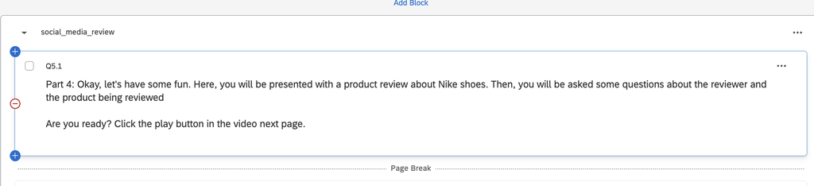

Revised product review instructions.

## 3.2 Prefer not to answer option

I added **Prefer not to answer** to the ethnicity question. This gives participants another choice if they do not want to provide this demographic information.

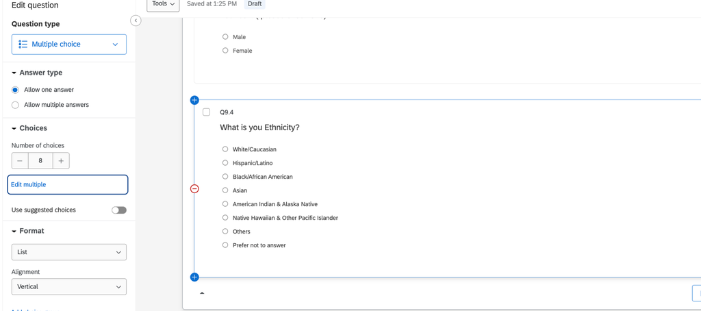

Demographic question with the Prefer not to answer option.

These changes improve the survey because the social media questions collect more specific information, the time question has better data completeness, and the demographic section gives participants more choice.

# 4 Summary

The main changes in this project were:

1. A Randomizer was added to compare a social media review and an advertisement.
2. Q2.2 was changed to allow participants to select all social media platforms they use.
3. Q58 uses carry forward statements to measure time for each selected platform.
4. Force response was added to Q58.
5. The product review instructions were made clearer.
6. A Prefer not to answer option was added to the ethnicity question.

The survey was previewed to check the two experimental conditions and the new social media questions.

# 5 Appendix